# Assignment 2 - Linear Regression

Jacqueline Liu

This assignment is based on the material covered in James et al. We will subsequently open up solutions to the problem sets.

## Exercise 2.1

This question involves the use of multiple linear regression on the `Auto` data set. So load the data set from the `ISLR` package first.

If the following code chunk returns an error, you most likely have to install the `ISLR` package first. Use `install.packages("ISLR")` if this is the case.

```r
data("Auto", package = "ISLR")
```

1. Produce a scatterplot matrix which includes all of the variables in the data set.

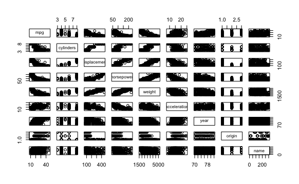

```r
pairs(Auto)
```

2. Compute the matrix of correlations between the variables using the function `cor()`. You will need to exclude the `name` variable, which is qualitative.

```r
cor(subset(Auto, select=-name))
```

```
                    mpg  cylinders displacement horsepower     weight
mpg           1.0000000 -0.7776175   -0.8051269 -0.7784268 -0.8322442
cylinders    -0.7776175  1.0000000    0.9508233  0.8429834  0.8975273
displacement -0.8051269  0.9508233    1.0000000  0.8972570  0.9329944
horsepower   -0.7784268  0.8429834    0.8972570  1.0000000  0.8645377
weight       -0.8322442  0.8975273    0.9329944  0.8645377  1.0000000
acceleration  0.4233285 -0.5046834   -0.5438005 -0.6891955 -0.4168392
year          0.5805410 -0.3456474   -0.3698552 -0.4163615 -0.3091199
origin        0.5652088 -0.5689316   -0.6145351 -0.4551715 -0.5850054
             acceleration       year     origin
mpg             0.4233285  0.5805410  0.5652088
cylinders      -0.5046834 -0.3456474 -0.5689316
displacement   -0.5438005 -0.3698552 -0.6145351
horsepower     -0.6891955 -0.4163615 -0.4551715
weight         -0.4168392 -0.3091199 -0.5850054
acceleration    1.0000000  0.2903161  0.2127458
year            0.2903161  1.0000000  0.1815277
origin          0.2127458  0.1815277  1.0000000
```

3. Use the `lm()` function to perform a multiple linear regression with `mpg` as the response and all other variables except `name` as the predictors. Use the `summary()` function to print the results. Comment on the output. For instance:

```r
lm.fit = lm(mpg ~.-name, data = Auto)
summary(lm.fit)
```

```
Call:
lm(formula = mpg ~ . - name, data = Auto)

Residuals:
    Min      1Q  Median      3Q     Max
-9.5903 -2.1565 -0.1169  1.8690 13.0604

Coefficients:
               Estimate Std. Error t value Pr(>|t|)
(Intercept)  -17.218435   4.644294  -3.707  0.00024 ***
cylinders     -0.493376   0.323282  -1.526  0.12780
displacement   0.019896   0.007515   2.647  0.00844 **
horsepower    -0.016951   0.013787  -1.230  0.21963
weight        -0.006474   0.000652  -9.929  < 2e-16 ***
acceleration   0.080576   0.098845   0.815  0.41548
year           0.750773   0.050973  14.729  < 2e-16 ***
origin         1.426141   0.278136   5.127 4.67e-07 ***
---
Signif. codes:  0 ‘***’ 0.001 ‘**’ 0.01 ‘*’ 0.05 ‘.’ 0.1 ‘ ’ 1

Residual standard error: 3.328 on 384 degrees of freedom
Multiple R-squared:  0.8215,    Adjusted R-squared:  0.8182
F-statistic: 252.4 on 7 and 384 DF,  p-value: < 2.2e-16
```

```
i. Is there a relationship between the predictors and the response?
ii. Which predictors appear to have a statistically significant relationship to the response?
iii. What does the coefficient for the `year` variable suggest?
```

**i. Is there a relationship between the predictors and the response?**

Yes. There is a relationship between the predictors and the response. We tested this by fitting a multiple regression model and testing the null hypothesis that:
$$H_0: \beta_{cylinders} = \beta_{displacement} = \beta_{horsepower}
= \beta_{weight} = \beta_{acceleration} = \beta_{year} = \beta_{origin} = 0$$
The F-statistic returned was very large at 252.4. Furthermore, the p-value associated with the F-statistic was very small. This enables us to reject the null hypothesis that there is no relationship between the predictors.

**ii. Which predictors appear to have a statistically significant relationship to the response?**

The predictors `displacement`, `weight`, `year`, and `origin` appear to have a statistically significant relationship to the response at 99% significant level.

**iii. What does the coefficient for the `year` variable suggest?**

The coefficient for the `year` variable suggests that as the year increases by 1 year, the miles-per-gallon (MPG) increases by 0.75 units. This means that newer cars have higher MPG and are more fuel efficient.

4. Use the `*` and `:` symbols to fit linear regression models with interaction effects. Do any interactions appear to be statistically significant?

```r
# Including interaction terms
lm.fit1 = lm(mpg ~.-name+cylinders*displacement, data = Auto)
summary(lm.fit1)

lm.fit2 = lm(mpg ~.-name+cylinders*weight, data = Auto)
summary(lm.fit2)

lm.fit3 = lm(mpg ~.-name+displacement*weight, data = Auto)
summary(lm.fit3)

lm.fit4 = lm(mpg ~.-name+displacement*horsepower, data = Auto)
summary(lm.fit4)

lm.fit5 = lm(mpg ~.-name+horsepower*cylinders, data = Auto)
summary(lm.fit5)

lm.fit6 = lm(mpg ~.-name+weight*horsepower, data = Auto)
summary(lm.fit6)
```

[output not shown]

I arbitrarily selected the variables to include as interaction terms based on the correlation matrix. Variables that were highly correlated with another variable (e.g. >0.85) were used in the interaction terms. I only included one interaction term in each model at first. In each model, the interaction term was always highly statistically significant (p-value << 0).

I then tried including two interaction terms in one model and found that while both interaction terms were statistically significant, the `cylinders:displacement` term had a much higher p-value than the `horsepower:weight` term.

```r
# Including more than one interaction term in a model
lm.fit7 = lm(mpg ~.-name+cylinders*displacement+horsepower*weight, data = Auto)
summary(lm.fit7)
```

[output not shown]

## Exercise 2.2

This question should be answered using the `Carseats` dataset from the `ISLR` package. So load the data set from the `ISLR` package first.

```r
data("Carseats", package = "ISLR")
```

```r
# Inspecting structure of dataset
str(Carseats)
```

```
'data.frame':   400 obs. of  11 variables:
 $ Sales      : num  9.5 11.22 10.06 7.4 4.15 ...
 $ CompPrice  : num  138 111 113 117 141 124 115 136 132 132 ...
 $ Income     : num  73 48 35 100 64 113 105 81 110 113 ...
 $ Advertising: num  11 16 10 4 3 13 0 15 0 0 ...
 $ Population : num  276 260 269 466 340 501 45 425 108 131 ...
 $ Price      : num  120 83 80 97 128 72 108 120 124 124 ...
 $ ShelveLoc  : Factor w/ 3 levels "Bad","Good","Medium": 1 2 3 3 1 1 3 2 3 3 ...
 $ Age        : num  42 65 59 55 38 78 71 67 76 76 ...
 $ Education  : num  17 10 12 14 13 16 15 10 10 17 ...
 $ Urban      : Factor w/ 2 levels "No","Yes": 2 2 2 2 2 1 2 2 1 1 ...
 $ US         : Factor w/ 2 levels "No","Yes": 2 2 2 2 1 2 1 2 1 2 ...
```

```r
# Summary
summary(Carseats)
```

```
     Sales          CompPrice       Income        Advertising
 Min.   : 0.000   Min.   : 77   Min.   : 21.00   Min.   : 0.000
 1st Qu.: 5.390   1st Qu.:115   1st Qu.: 42.75   1st Qu.: 0.000
 Median : 7.490   Median :125   Median : 69.00   Median : 5.000
 Mean   : 7.496   Mean   :125   Mean   : 68.66   Mean   : 6.635
 3rd Qu.: 9.320   3rd Qu.:135   3rd Qu.: 91.00   3rd Qu.:12.000
 Max.   :16.270   Max.   :175   Max.   :120.00   Max.   :29.000
   Population        Price        ShelveLoc        Age          Education
 Min.   : 10.0   Min.   : 24.0   Bad   : 96   Min.   :25.00   Min.   :10.0
 1st Qu.:139.0   1st Qu.:100.0   Good  : 85   1st Qu.:39.75   1st Qu.:12.0
 Median :272.0   Median :117.0   Medium:219   Median :54.50   Median :14.0
 Mean   :264.8   Mean   :115.8                Mean   :53.32   Mean   :13.9
 3rd Qu.:398.5   3rd Qu.:131.0                3rd Qu.:66.00   3rd Qu.:16.0
 Max.   :509.0   Max.   :191.0                Max.   :80.00   Max.   :18.0
 Urban       US
 No :118   No :142
 Yes:282   Yes:258
```

1. Fit a multiple regression model to predict `Sales` using `Price`, `Urban`, and `US`.

```r
lm.fitsales = lm(Sales ~ Price + Urban + US, data = Carseats)
summary(lm.fitsales)
```

```
Call:
lm(formula = Sales ~ Price + Urban + US, data = Carseats)

Residuals:
    Min      1Q  Median      3Q     Max
-6.9206 -1.6220 -0.0564  1.5786  7.0581

Coefficients:
             Estimate Std. Error t value Pr(>|t|)
(Intercept) 13.043469   0.651012  20.036  < 2e-16 ***
Price       -0.054459   0.005242 -10.389  < 2e-16 ***
UrbanYes    -0.021916   0.271650  -0.081    0.936
USYes        1.200573   0.259042   4.635 4.86e-06 ***
---
Signif. codes:  0 ‘***’ 0.001 ‘**’ 0.01 ‘*’ 0.05 ‘.’ 0.1 ‘ ’ 1

Residual standard error: 2.472 on 396 degrees of freedom
Multiple R-squared:  0.2393,    Adjusted R-squared:  0.2335
F-statistic: 41.52 on 3 and 396 DF,  p-value: < 2.2e-16
```

2. Provide an interpretation of each coefficient in the model. Be careful – some of the variables in the model are qualitative!
- `Price`: The model suggests that there is a negative relationship between `Price` and `Sales`, and that this relationship is highly statistically significant (p-value < 0). As the price increases by 1 unit (e.g. dollar), sales decrease by approximately 0.05 units.
- `UrbanYes`: The model suggests that there is no significant relationship between `Urban` and `Sales`. Nonetheless, the coefficient suggests that there may be a negative relationship between these variables such that if the individual observation is in an urban area, sales would decrease by approximately 0.02 units.
- `USYes`: The model suggests that there is a positive relationship between `US` and `Sales`, and that this relationship is highly statistically significant (p-value < 0). If the individual observation is in the US, sales would increase by approximately 1.20 units.
- Intercept: The coefficient for the intercept is also highly statistically significant (p-value < 0). If the price is 0 units, and the individual observation is not in an urban area and not in the US, sales would increase by approximately 13 units.
3. Write out the model in equation form, being careful to handle the qualitative variables properly.

$$Sales = 13.04 - 0.05(Price) - 0.02(UrbanYes) + 1.20(USYes) + \epsilon$$

4. For which of the predictors can you reject the null hypothesis $H_0 : \beta_j =0$?

I can reject `Price` and `USYes` based on their respective p-values.

5. On the basis of your response to the previous question, fit a smaller model that only uses the predictors for which there is evidence of association with the outcome.

```r
lm.fitsales1 = lm(Sales ~ Price + US, data = Carseats)
summary(lm.fitsales1)
```

```
Call:
lm(formula = Sales ~ Price + US, data = Carseats)

Residuals:
    Min      1Q  Median      3Q     Max
-6.9269 -1.6286 -0.0574  1.5766  7.0515

Coefficients:
            Estimate Std. Error t value Pr(>|t|)
(Intercept) 13.03079    0.63098  20.652  < 2e-16 ***
Price       -0.05448    0.00523 -10.416  < 2e-16 ***
USYes        1.19964    0.25846   4.641 4.71e-06 ***
---
Signif. codes:  0 ‘***’ 0.001 ‘**’ 0.01 ‘*’ 0.05 ‘.’ 0.1 ‘ ’ 1

Residual standard error: 2.469 on 397 degrees of freedom
Multiple R-squared:  0.2393,    Adjusted R-squared:  0.2354
F-statistic: 62.43 on 2 and 397 DF,  p-value: < 2.2e-16
```

6. How well do the models in (a) and (e) fit the data?

7. Using the model from (e), obtain 95% confidence intervals for the coefficient(s).

```r
confint(lm.fitsales1, level = 0.95)
```

```
                  2.5 %      97.5 %
(Intercept) 11.79032020 14.27126531
Price       -0.06475984 -0.04419543
USYes        0.69151957  1.70776632
```